# Cleaning Tick Data

### Plotting survival curve based on mean values of variables

[figure not shown]

```r
## create survfit object and plot
tick19surv_fit<- predict(tick19surv_model)
plot(tick19surv_fit, col=c("red", "blue", "green")[tick19clean$exclosure])
```

### Instead, we want to plot a curve that indicates how survival changes with our variables of interest

- using “Cox Proportional Hazards Models in R” (in Evernote) p. 7
- we will first look at climate, holding all other variables to their mean (but we only have categorical variables…)
- the documentation I’m following says that for “dummy” variables ( I think it means categorical?), the “average value” is the proportion coded “Control” in the data set AND I HAVE NO IDEA WHAT THAT MEANS but I’m gonna try it
- currently not working so everything is hashtagged out

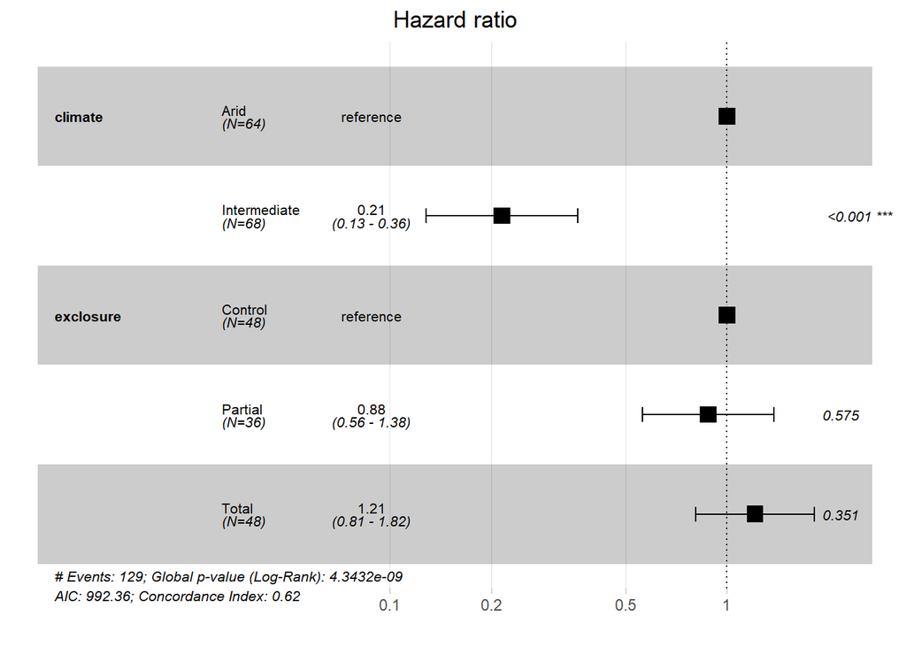

```r
# forest plots are a fun way to visualize model summary
ggforest(tick19surv_model3)
```

```r
#tick19_climate <- with(tick19clean, data.frame(climate = as.factor(c("Arid", "Intermediate")), exclosure = as.factor(rep(mean(exclosure == "Total"),2)), block = rep(mean(block)), microclimate = rep("open"),2))
# ^ this didn't work, see below

# coding a "categorical" variable didn't work at all, so i held it constant at "Total" exclosure for this figure
# I will then need to make another figure later for "Partial" exclosure
```

Creating the Total Exclosure x Climate Figure - plotting difference between intermediate and arid climates at total exclosure plots

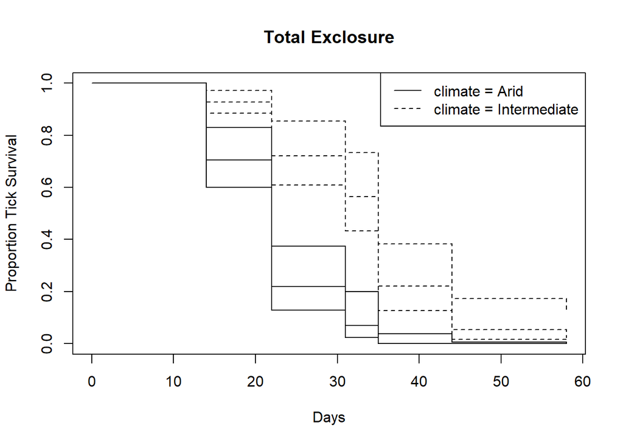

```r
tick19_climate_totalex <- with(tick19clean, data.frame(climate = c("Arid", "Intermediate"), exclosure = rep("Total"),2, block = rep(mean(block)), microclimate = rep("open"),2))

tick19_climate_totalex2 <- tick19_climate_totalex %>%
  select(climate, exclosure)

#now we predict

tickfit_totalex <- survfit(tick19surv_model3, newdata = tick19_climate_totalex2)
##getting an error that something isn't matching up

plot(tickfit_totalex,
     conf.int = TRUE,
     lty = c(1,2),
     ylab = "Proportion Tick Survival",
     xlab = "Days",
     main = "Total Exclosure")
     legend("topright",
            legend = c("climate = Arid", "climate = Intermediate"),
            lty = c(1,2))
```

```r
#ggadjustedcurves(tick19surv_model3,
#                 variable = climate,
#                 method = "conditional",
#                 data = tick19clean)

  #ggsurvplot(tickfit_totalex, data = tick19_climate_totalex2)
  # SUPER DUPER CUSTOMIZED PLOT
  # really want to make this work but currently having a hard time parsing the predicted curves and the ggsurv/ggadjusted curves model
#ggsurvplot(
#   tickfit_totalex,                            # survfit object with calculated statistics.
#   data = tick19_climate_totalex2,             # data used to fit survival curves.
#   risk.table = TRUE,       # show risk table.
#   pval = TRUE,             # show p-value of log-rank test.
#   conf.int = TRUE,         # show confidence intervals for
#                            # point estimates of survival curves.
#   xlim = c(0,60),          # present narrower X axis, but not affect
#                            # survival estimates.
#   xlab = "Time in days",   # customize X axis label.
#   break.time.by = 10,      # break X axis in time intervals by 500.
#   ggtheme = theme_light(), # customize plot and risk table with a theme.
# risk.table.y.text.col = T, # colour risk table text annotations.
#  risk.table.y.text = FALSE # show bars instead of names in text annotations in legend of risk table
#  #legend.labs = c()
#)
```

Creating the Partial Exclosure x Climate figure

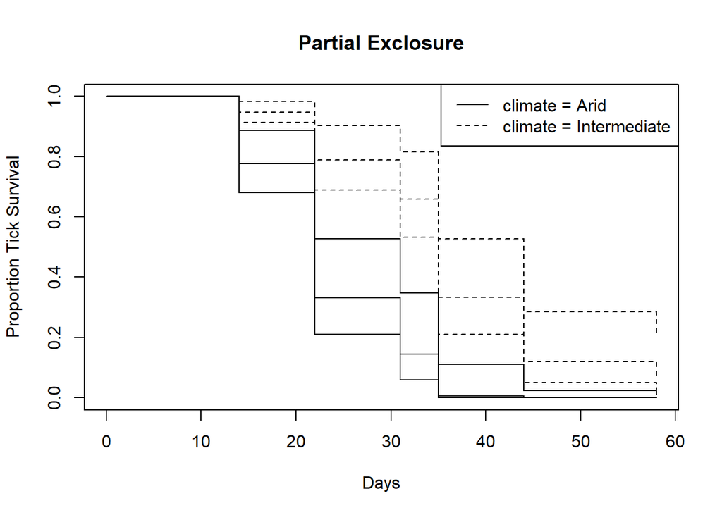

```r
tick19_climate_partialex <- with(tick19clean, data.frame(climate = c("Arid", "Intermediate"), exclosure = rep("Partial"),2, block = rep(mean(block)), microclimate = rep("open"),2))

tick19_climate_partialex2 <- tick19_climate_partialex %>%
  select(climate, exclosure)

#now we predict

tickfit_partialex <- survfit(tick19surv_model3, newdata = tick19_climate_partialex2)
##getting an error that something isn't matching up

plot(tickfit_partialex,
     conf.int = TRUE,
     lty = c(1,2),
     ylab = "Proportion Tick Survival",
     xlab = "Days",
     main = "Partial Exclosure")
     legend("topright",
            legend = c("climate = Arid", "climate = Intermediate"),
            lty = c(1,2))
```

Creating the Control Exclosure x Climate figure

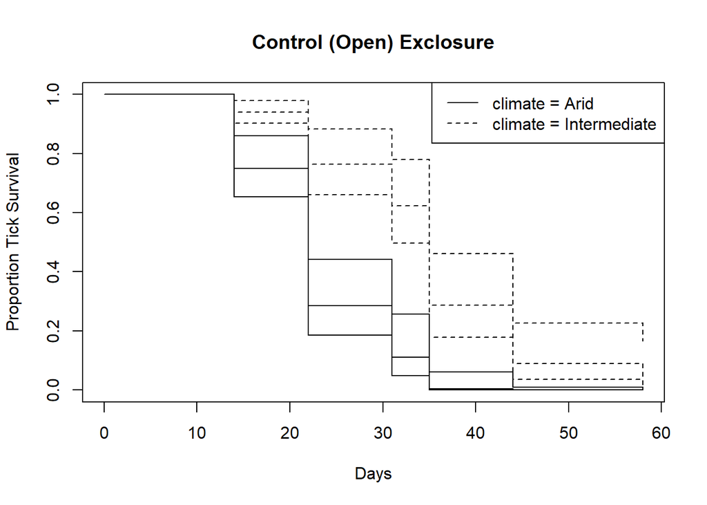

```r
tick19_climate_controlex <- with(tick19clean, data.frame(climate = c("Arid", "Intermediate"), exclosure = rep("Control"),2, block = rep(mean(block)), microclimate = rep("open"),2))

tick19_climate_controlex2 <- tick19_climate_controlex %>%
  select(climate, exclosure)

#now we predict

tickfit_controlex <- survfit(tick19surv_model3, newdata = tick19_climate_controlex2)
##getting an error that something isn't matching up

plot(tickfit_controlex,
     conf.int = TRUE,
     lty = c(1,2),
     ylab = "Proportion Tick Survival",
     xlab = "Days",
     main = "Control (Open) Exclosure")
     legend("topright",
            legend = c("climate = Arid", "climate = Intermediate"),
            lty = c(1,2))
```